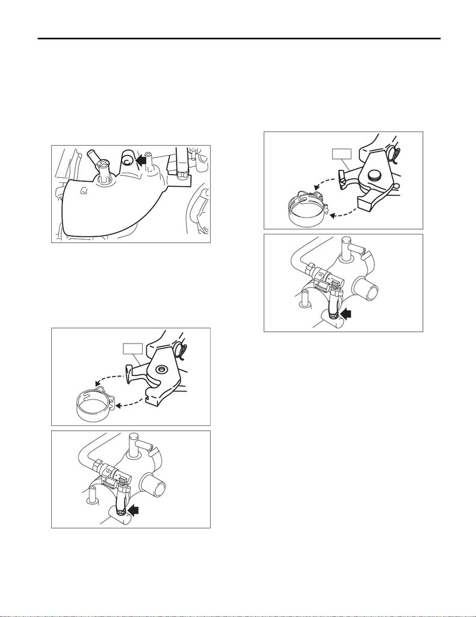

Intake Duct

INTAKE (INDUCTION)

5. Intake Duct

A: REMOVAL

1) Disconnect the ground cable from battery.

2) Remove the intake manifold. <Ref. to FU(STI)-

17, REMOVAL, Intake Manifold.>

3) Remove the sensor, engine harness and fuel

pipe from the intake manifold. <Ref. to FU(STI)-25,

DISASSEMBLY, Intake Manifold.>

4) Remove the intake duct from intake manifold.

5) Remove the PCV hose assembly and air by-

pass hose from the intake duct.

NOTE:

To disconnect the PCV hose assembly, fit the cut

outs of the ST with the protrusions on the clamp as

shown in the figure, squeeze the ST's handles to-

gether and unlock the clamp.

ST 18353AA000 CLAMP PLIERS

B: INSTALLATION

Install in the reverse order of removal.

NOTE:

Use a new clamp. To connect the PCV hose as-

sembly, fit the cut outs of the ST with the protru-

sions on the clamp as shown in the figure, squeeze

the ST's handles together and lock the clamp.

ST 18353AA000 CLAMP PLIERS

Tightening torque:

17 N·m (1.7 kgf-m, 12.5 ft-lb)

C: INSPECTION

Check that the intake duct has no deformation,

cracks or other damages.

ST

ST